# Analysis of TCGA lung adenocarcinoma cancer (LUAD)

### 4.1.2 Compute optimo PSI inside G0 (psi < 69.41)

```
## [1] 44.0071
```

[interactive chart not shown]

#### 4.1.2.1 OS and RFS in G0 using optimo psi 44

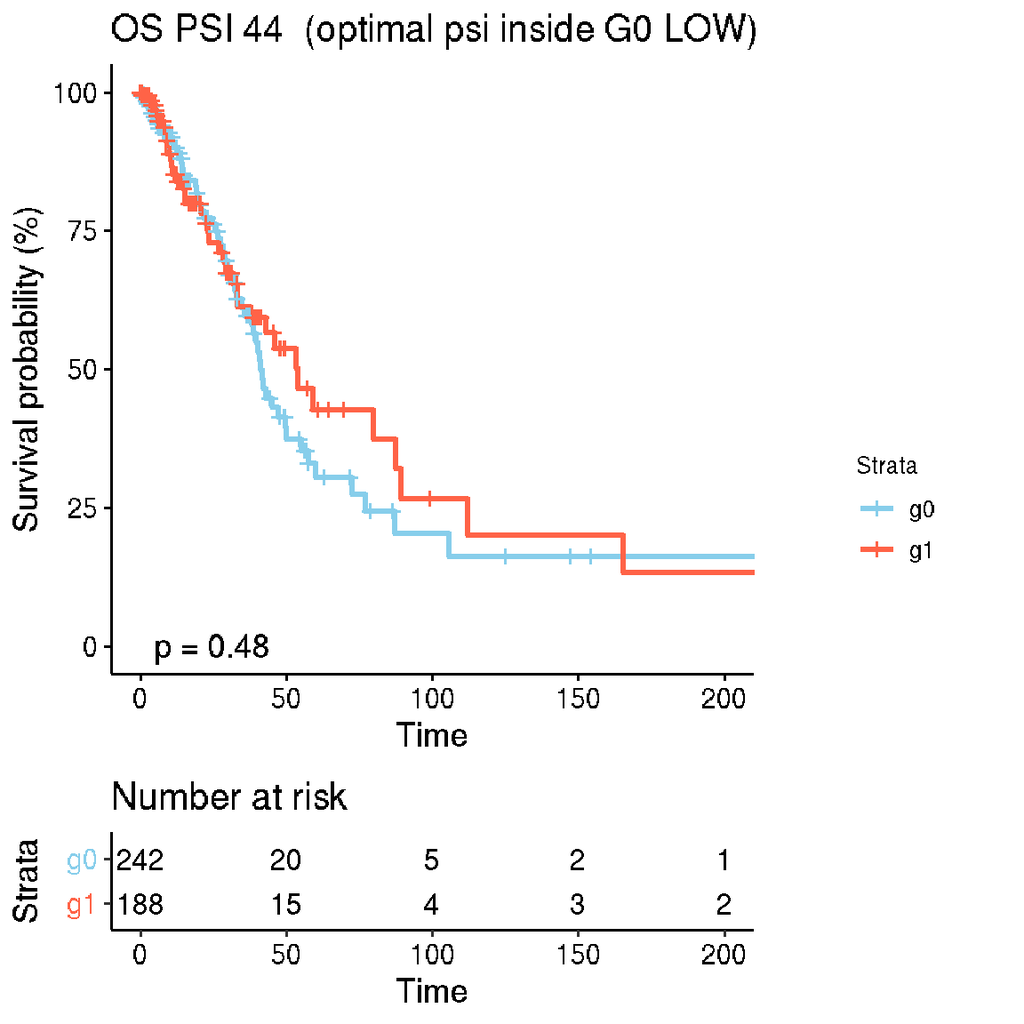

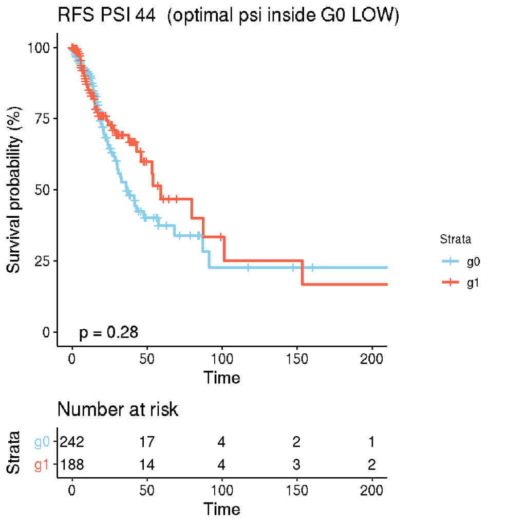

### 4.1.3 Compute optimo PSI inside G1 (psi >69.41)

```
## [1] 83.40527
```

```
## [1] 0.129
```

[interactive chart not shown]

#### 4.1.3.1 OS and RFS in G1 using optimo psi 83.41

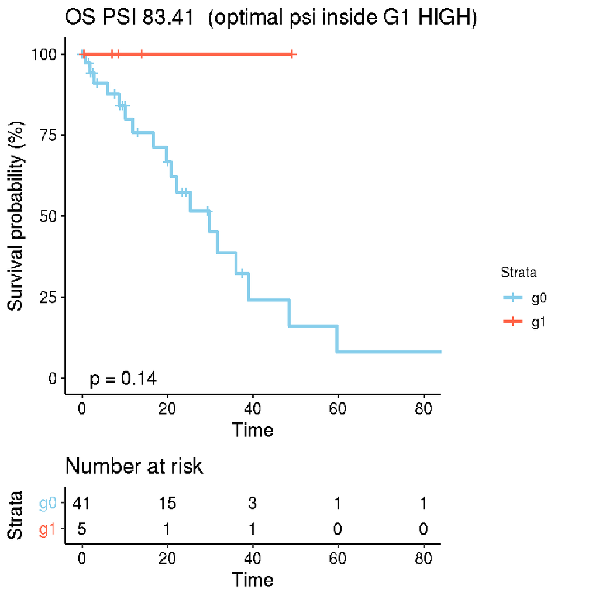

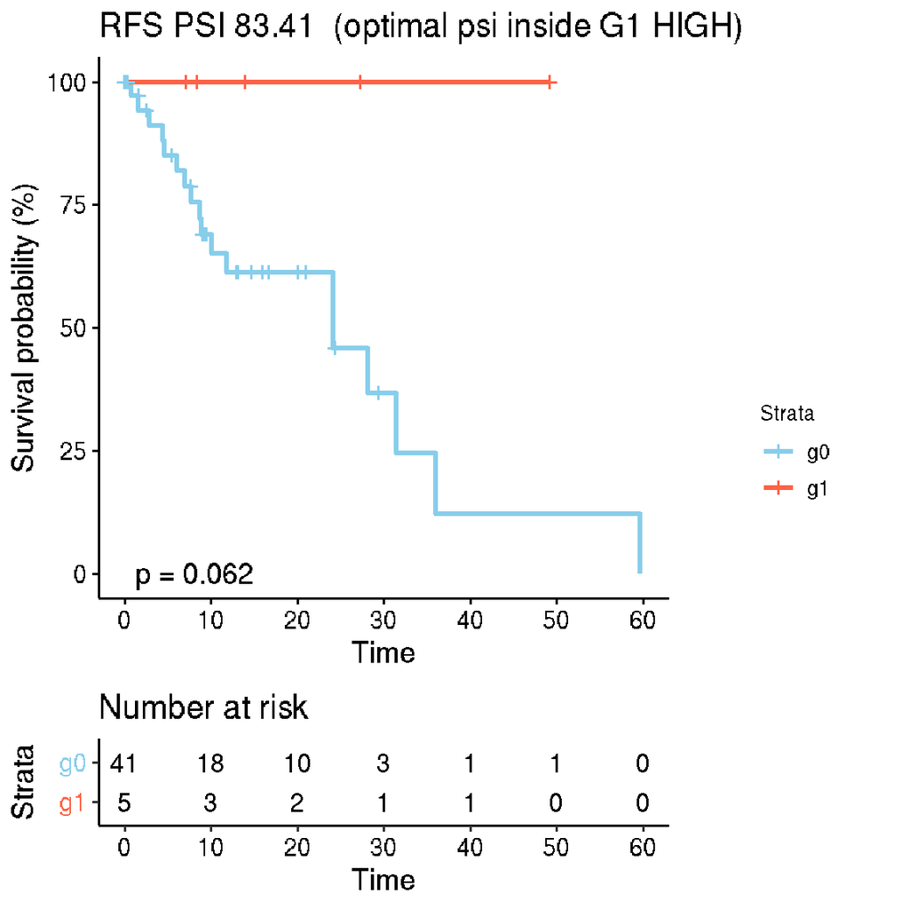

## 4.2 (2nd strategy) Scan pvalue across PSI values (whole dataset)

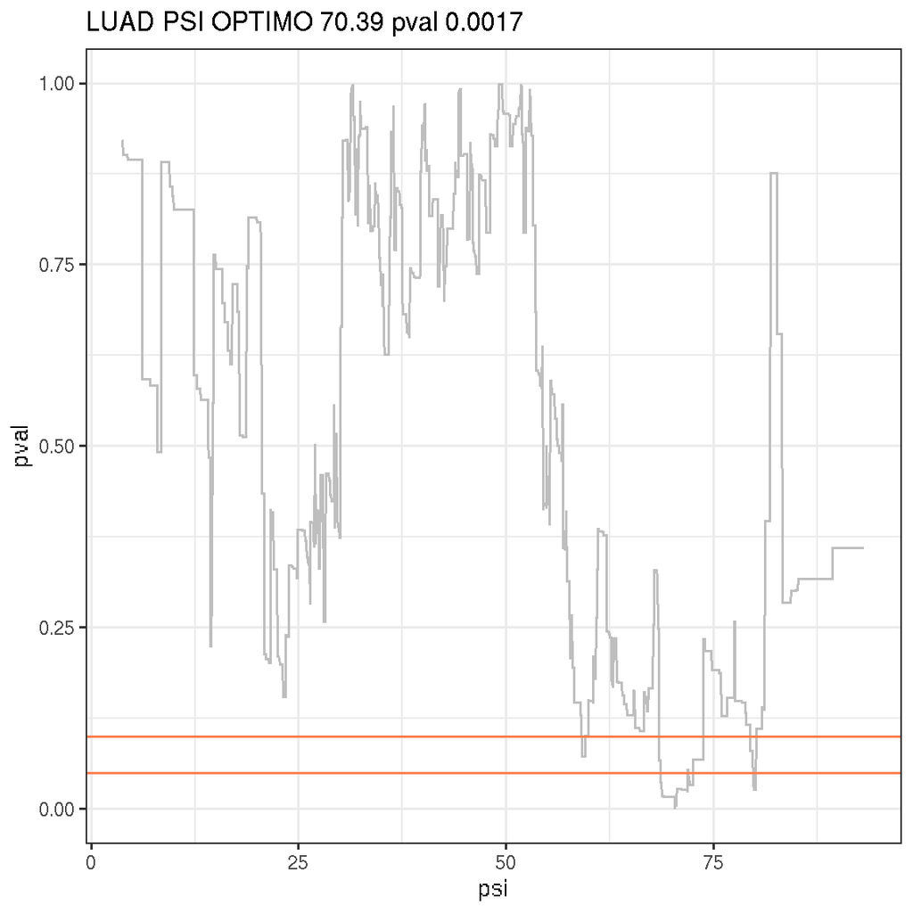

### 4.2.1 OS and RFS plots **whole dataset** using optimo PSI (70.4)

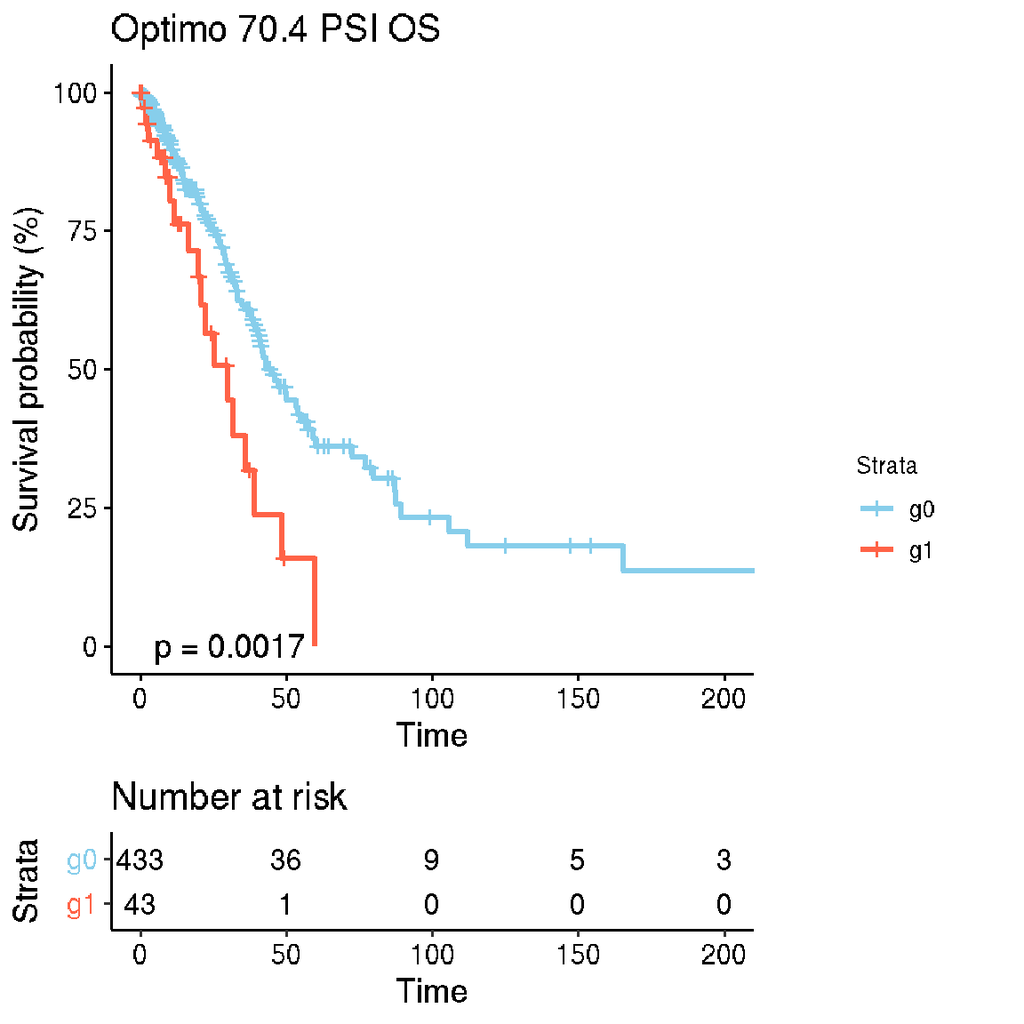

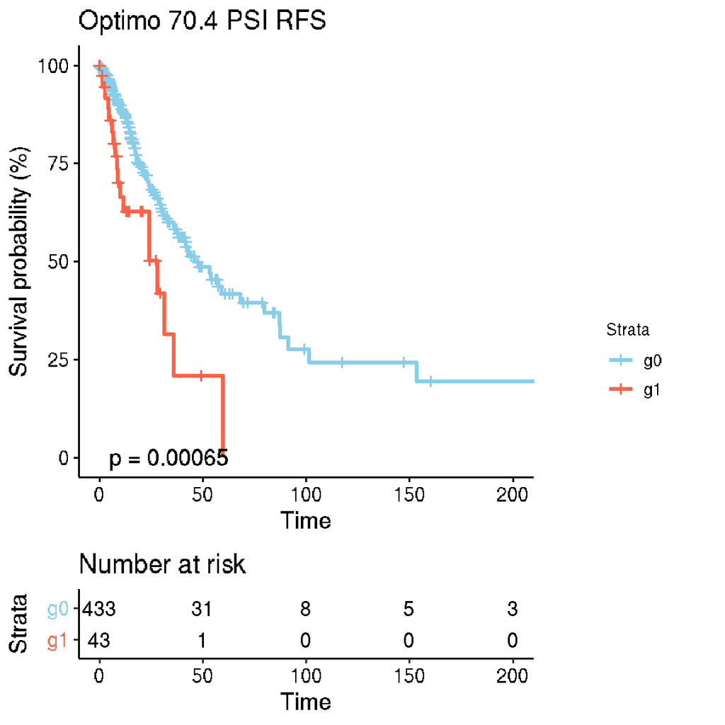

### 4.2.2 Scan for optimal in G0 (psi <70.4)

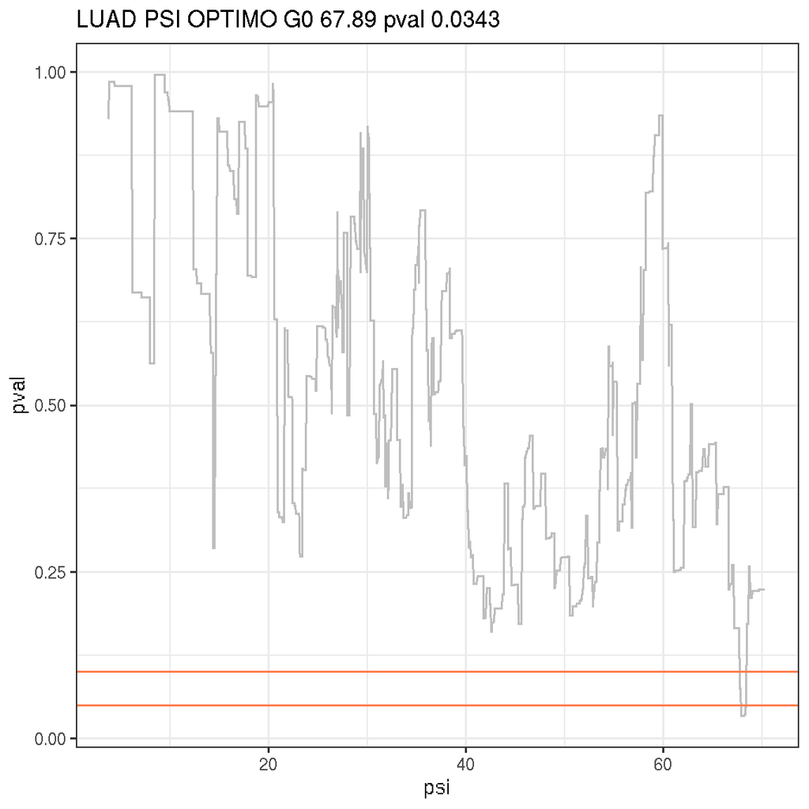

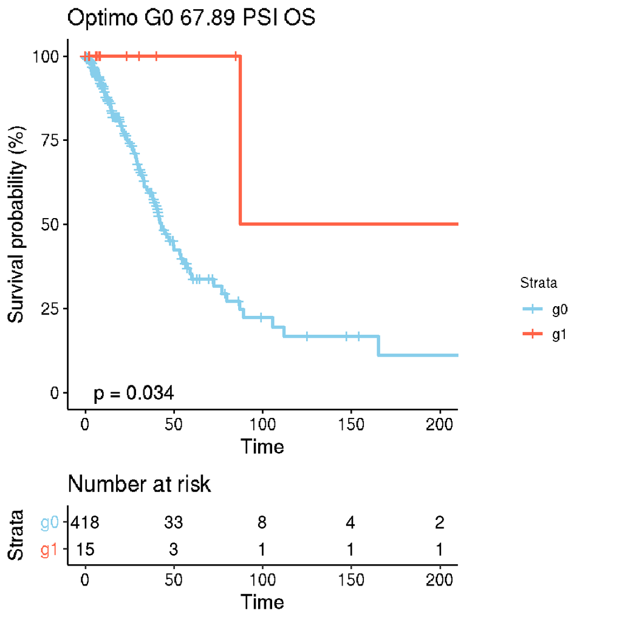

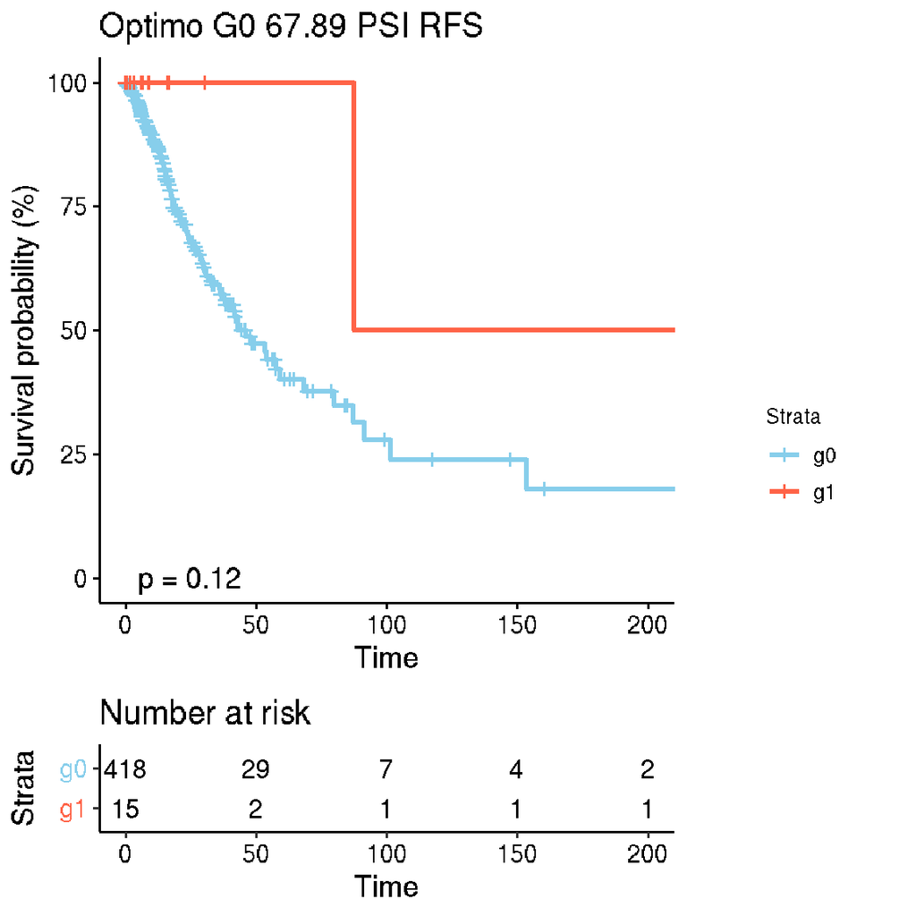

### 4.2.3 Scan for optimal in G1 (psi >70.4)

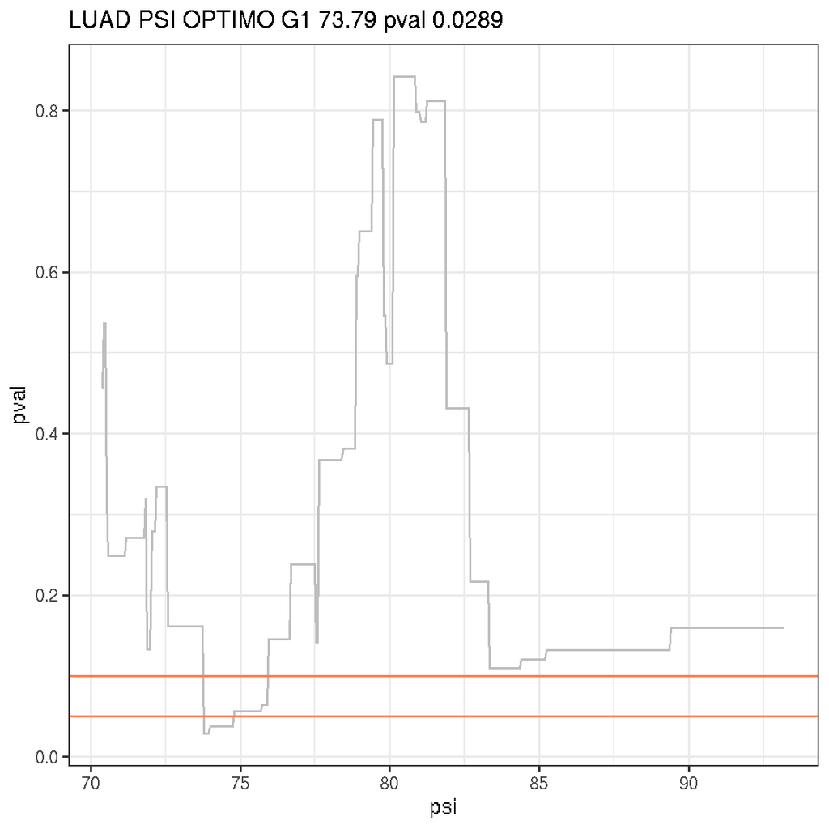

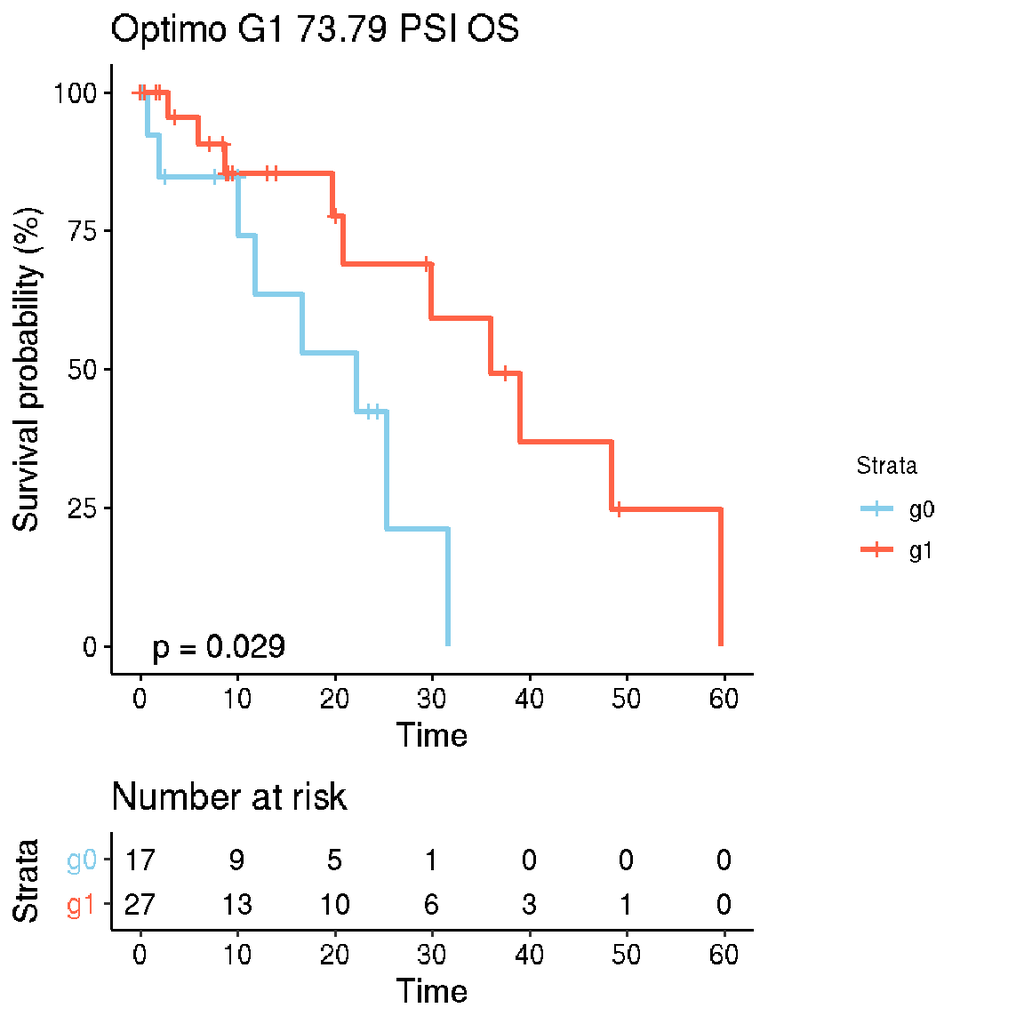

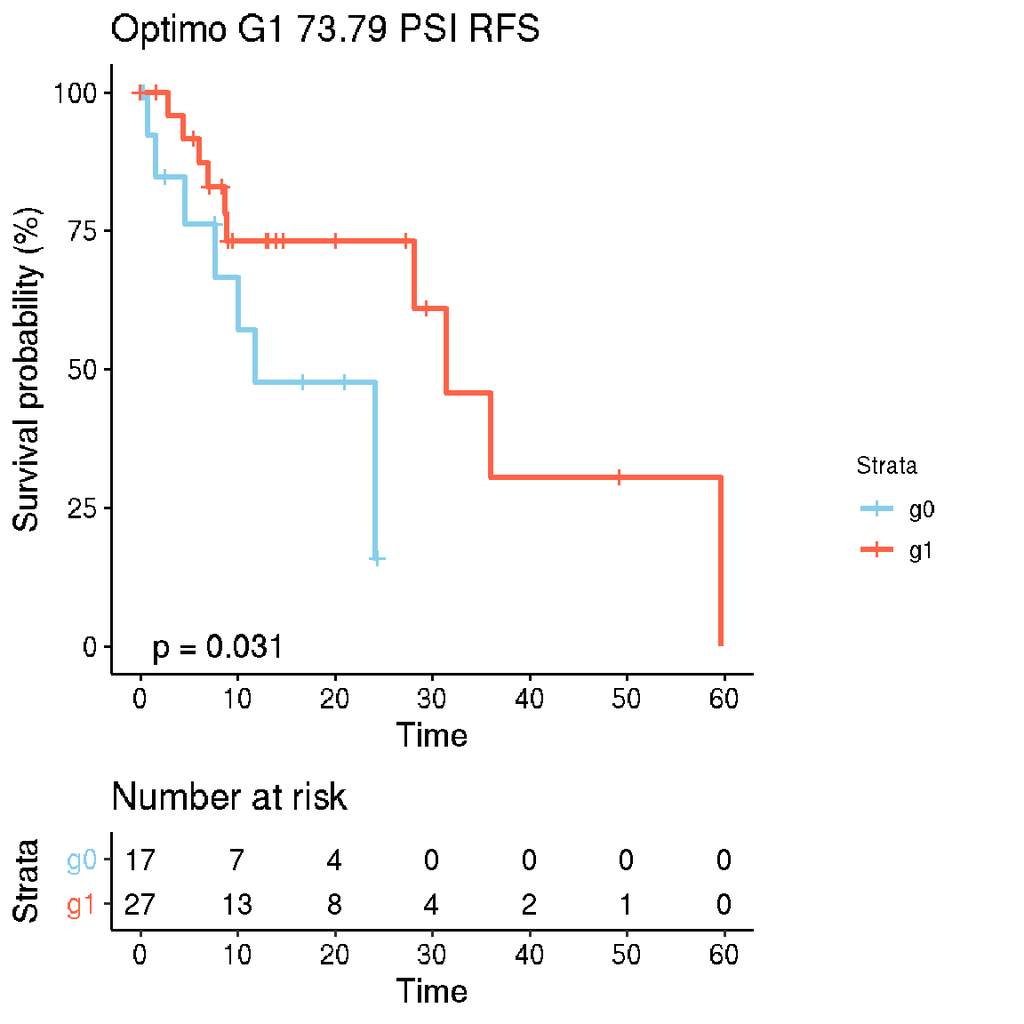

## 4.3 New analysis 25.05

Cuando separamos los LUAD TCGA patients por supervivencia hacemos dos grupos >0.69, donde los pacientes mueren de forma más temprana. Sin embargo, en este grupo me gustaría ver algunos más detalles, podríamos ver la distribución, dentro de ese grupo por: * genero, * estadio y * mutaciones en los tumores. A ver si los pacientes que tienen PSI >0.69 tienen más cosas en común.

```
##
##  g0  g1
## 430  46
```

```
## [1] 46 41
```

### 4.3.1 Divide G1 By gender, make g0=MALE, g1=FEMALE:

```
##
## female   male
##     21     25
```

```
##
## g0 g1
## 25 21
```

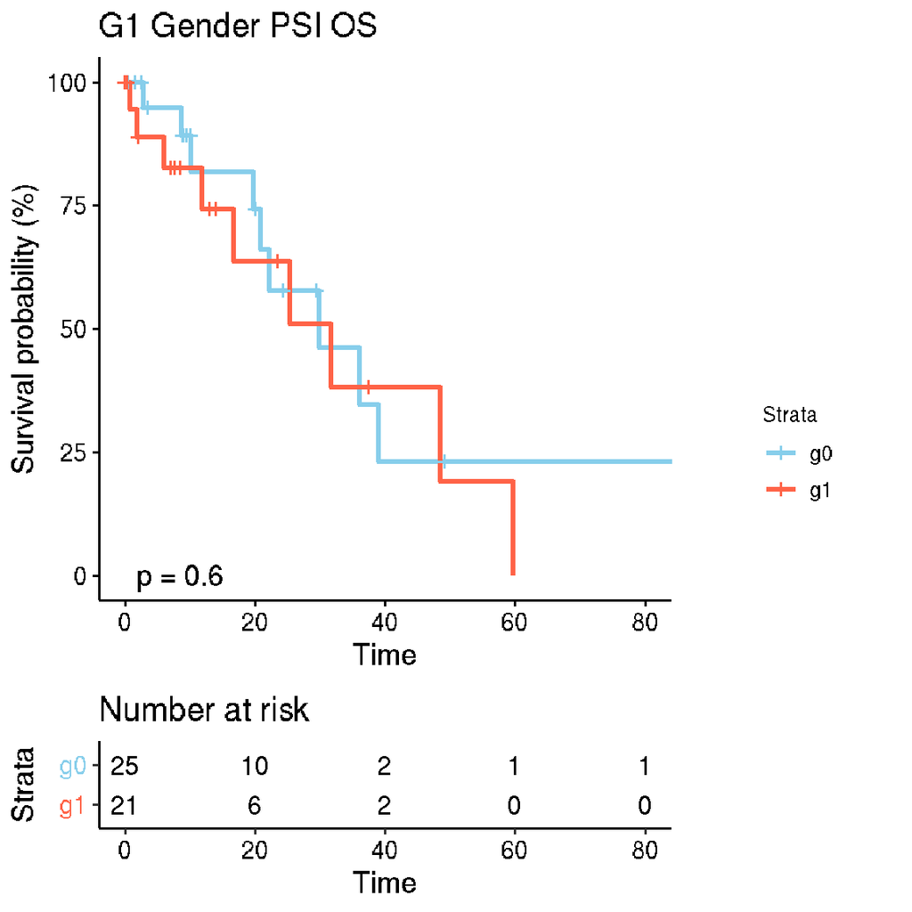

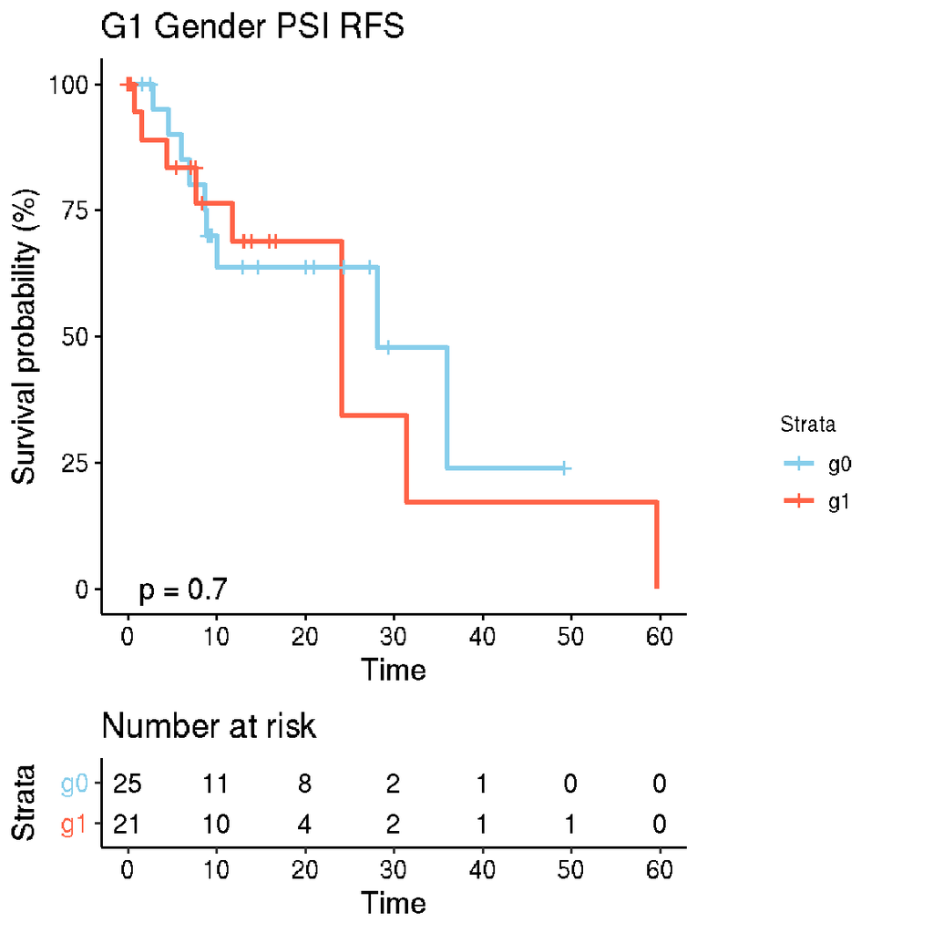

### 4.3.2 Divide G1 By AggStage, G0=early, G1=late:

```
##
## early  late
##    36     9
```

```
##
## g0 g1
## 37  9
```

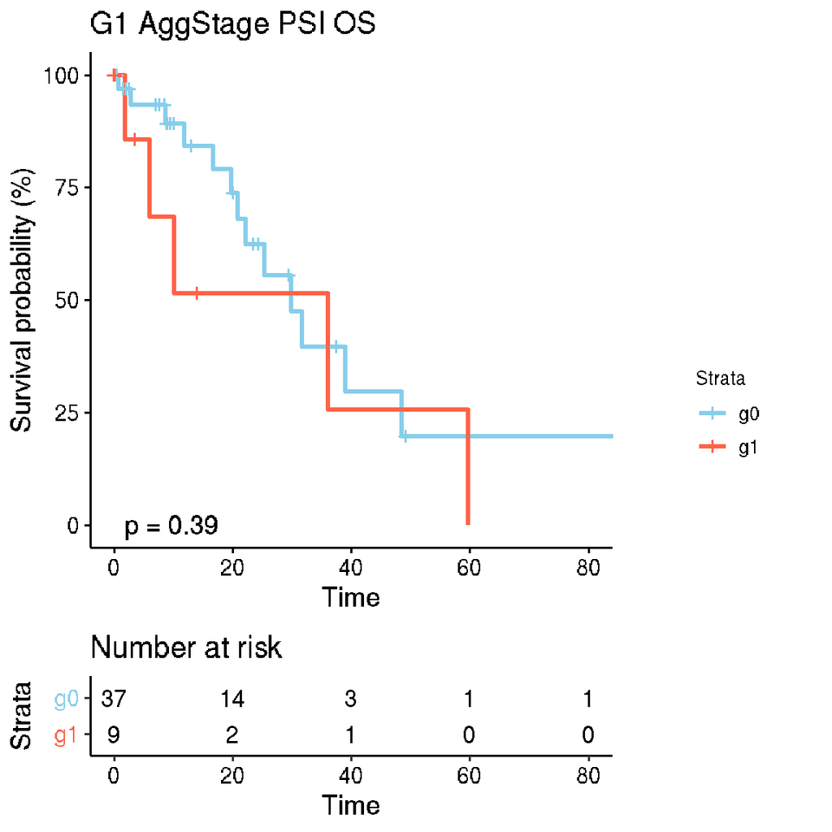

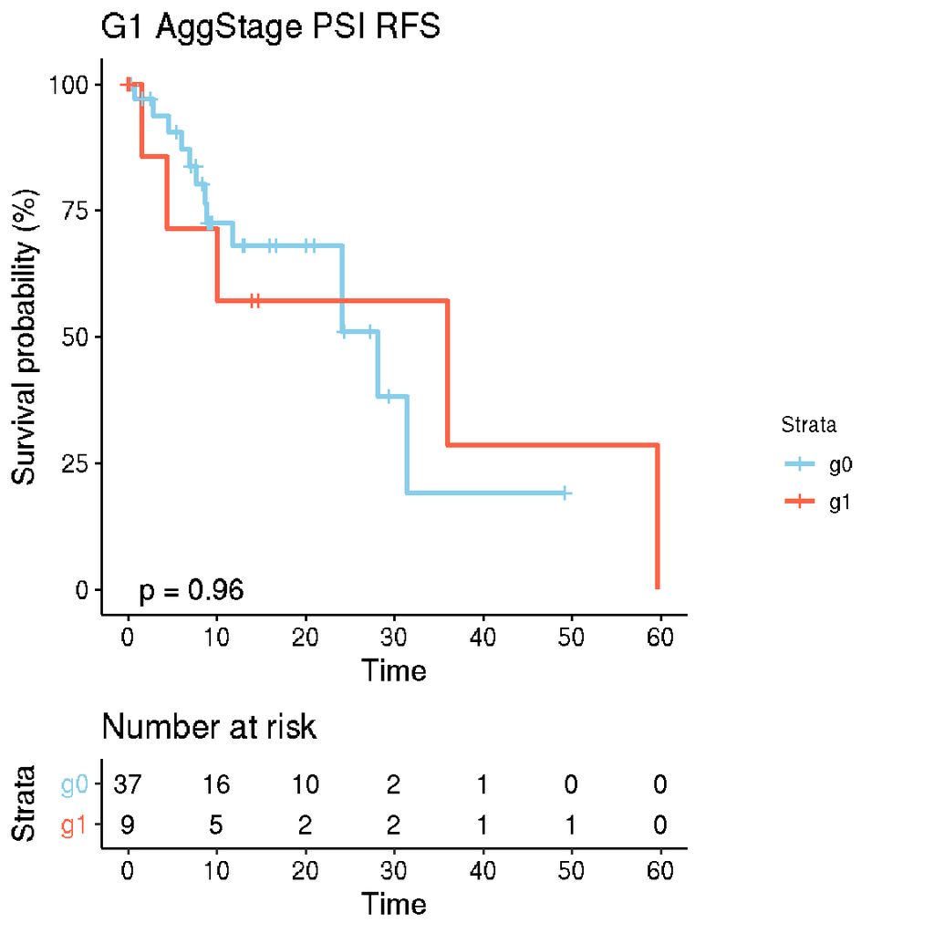

### 4.3.3 Check Mutations: in this small group (G1)

```
## [1] "EGFR performed"
```

```
##
## yes  no
##  12  34
```

```
## [1] "EGFR results"
```

```
##
## exon 19 deletion            l858r               ns            other
##                1                1               42                1
##            t790m
##                1
```

```
## [1] "kras mutation found"
```

```
##
##  no yes
##  43   3
```

```
## [1] "kras mutation result"
```

```
##
## g12c g12d   no
##    2    1   43
```

## 4.4 Gender analysis whole dataset

Viendo las diferencias significativas de NUMB exon 9 PSI male vs female. Me preguntaba si crees que esto podría tener un efecto en las gráficas de supervivencia.

```
##
## female   male
##    257    219
```

```
##
##  g0  g1
## 219 257
```

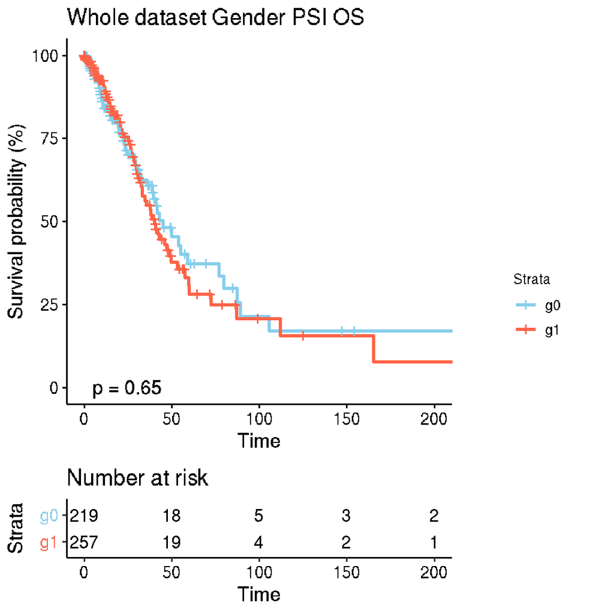

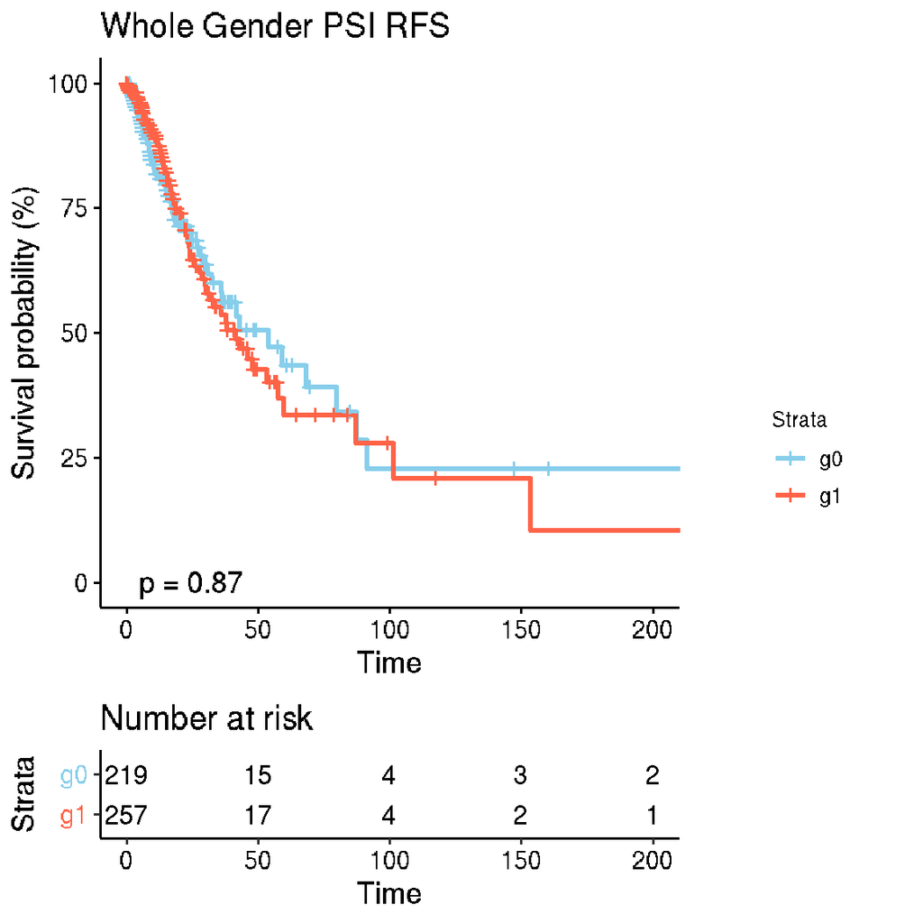